# RReject4 - RReject7

Author

Risk Rejection Team: Guannan Shen

Published

October 7, 2024

## RReject4 – RReject7

### Cronbach’s Alpha Measurement for RReject4 - RReject7

**Standardized Cronbach’s alpha for RReject4 - RReject7** is, 0.9412, a 95% Bootstrap CI based on 1000 samples is (0.9275, 0.9534).

There are 4 items, 527 sample units.

### Descriptive

- Q4 Overall, how much do you disagree or agree with your personal breast cancer risk estimate?
- Q5 In my opinion, my personal breast cancer risk estimate was believable.
- Q6 In my opinion, my personal breast cancer risk estimate was convincing.
- Q7 In my opinion, my personal breast cancer risk estimate was accurate.

#### Descriptive Summary of RReject4

Descriptive Summary of RReject4

| mean | median | min | max | variance | sd | n_missing |
| --- | --- | --- | --- | --- | --- | --- |
| 3.337761 | 3 | 1 | 5 | 1.535891 | 1.239311 | 0 |

#### Descriptive Summary of RReject5

Descriptive Summary of RReject5

| mean | median | min | max | variance | sd | n_missing |
| --- | --- | --- | --- | --- | --- | --- |
| 3.56167 | 4 | 1 | 5 | 1.394954 | 1.181082 | 0 |

#### Descriptive Summary of RReject6

Descriptive Summary of RReject6

| mean | median | min | max | variance | sd | n_missing |
| --- | --- | --- | --- | --- | --- | --- |
| 3.499051 | 4 | 1 | 5 | 1.436786 | 1.19866 | 0 |

#### Descriptive Summary of RReject7

Descriptive Summary of RReject7

| mean | median | min | max | variance | sd | n_missing |
| --- | --- | --- | --- | --- | --- | --- |
| 3.379507 | 3 | 1 | 5 | 1.418439 | 1.190982 | 0 |

| **Characteristic** | **N** | **N = 527** <sup>1</sup> |
| --- | --- | --- |
| RReject4 | 527 |  |
| Disagree a lot |  | 56 (11%) |
| Disagree a little |  | 66 (13%) |
| Neither agree nor disagree |  | 160 (30%) |
| Agree a little |  | 134 (25%) |
| Agree a lot |  | 111 (21%) |
| RReject5 | 527 |  |
| Disagree a lot |  | 44 (8.3%) |
| Disagree a little |  | 44 (8.3%) |
| Neither agree nor disagree |  | 137 (26%) |
| Agree a little |  | 176 (33%) |
| Agree a lot |  | 126 (24%) |
| RReject6 | 527 |  |
| Disagree a lot |  | 46 (8.7%) |
| Disagree a little |  | 48 (9.1%) |
| Neither agree nor disagree |  | 156 (30%) |
| Agree a little |  | 151 (29%) |
| Agree a lot |  | 126 (24%) |
| RReject7 | 527 |  |
| Disagree a lot |  | 48 (9.1%) |
| Disagree a little |  | 64 (12%) |
| Neither agree nor disagree |  | 158 (30%) |
| Agree a little |  | 154 (29%) |
| Agree a lot |  | 103 (20%) |

<sup>1</sup> n (%)

## Figures

### Diff of RReject1 and Risk Estimates VS. RReject4 - 7

#### All values

**Important:** Manually fix typos in RReject1.

- ResponseId abs_risk_rounded RReject1 RReject_diff RReject2
- R_1LUtAxnLeszwqkC 8 **0.008** -7.992 Using the percent above **(Change to 8)**
- R_28RFoTia7YU40yO 11 **0.011** -10.989 Same **(Change to 11)**
- R_3Mo4X2lgxig4ct9 16 **10000** 9984 Noa **(Change to 1000)**

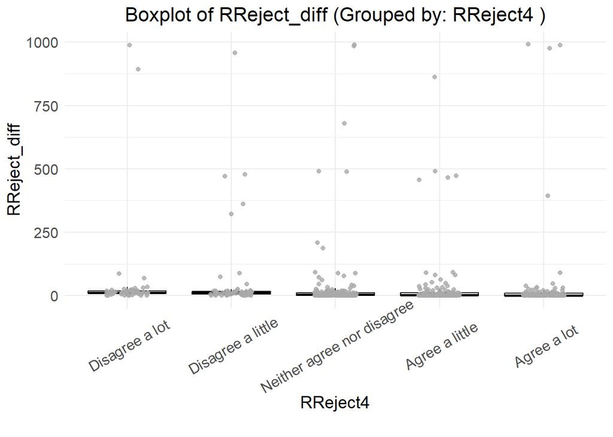

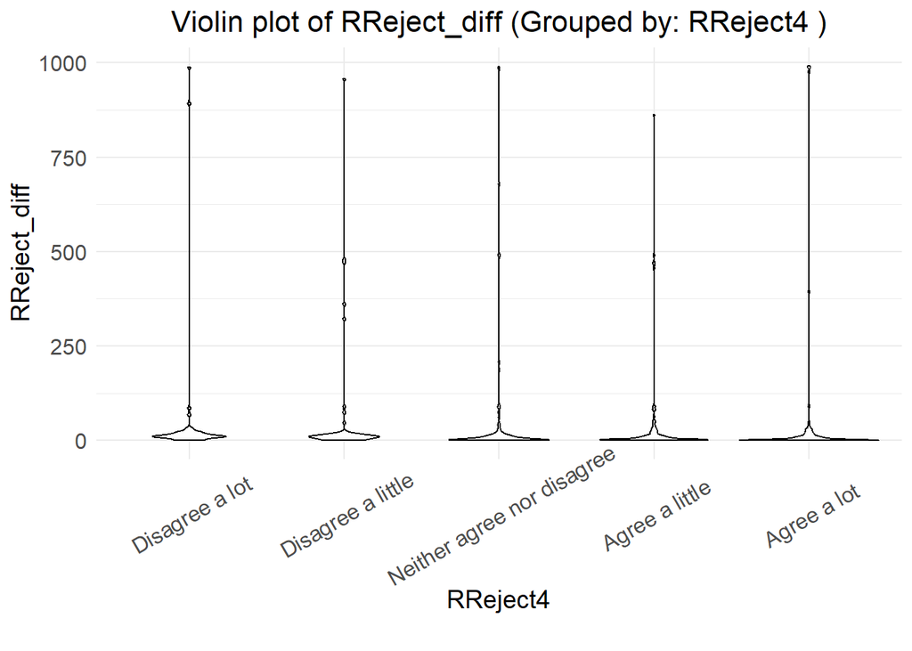

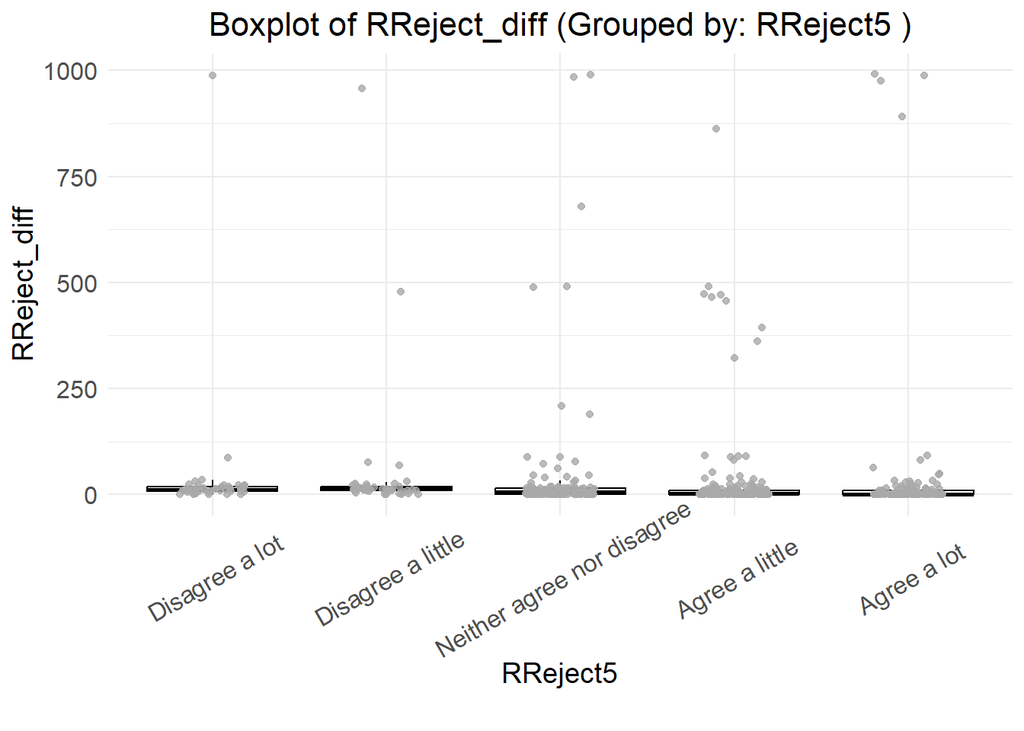

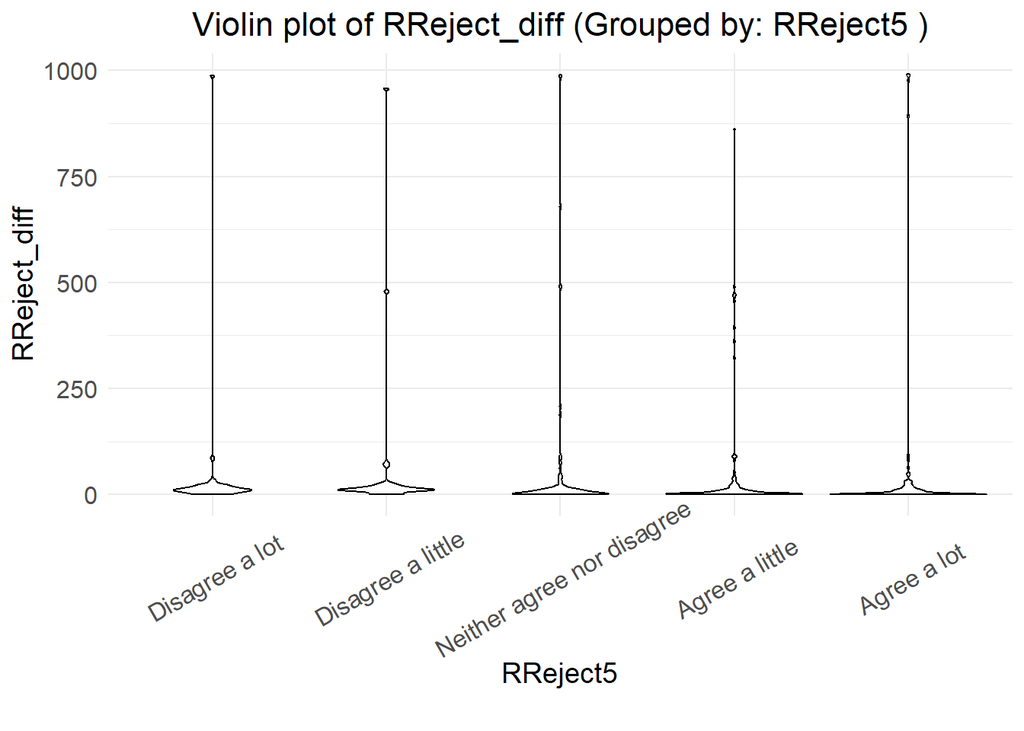

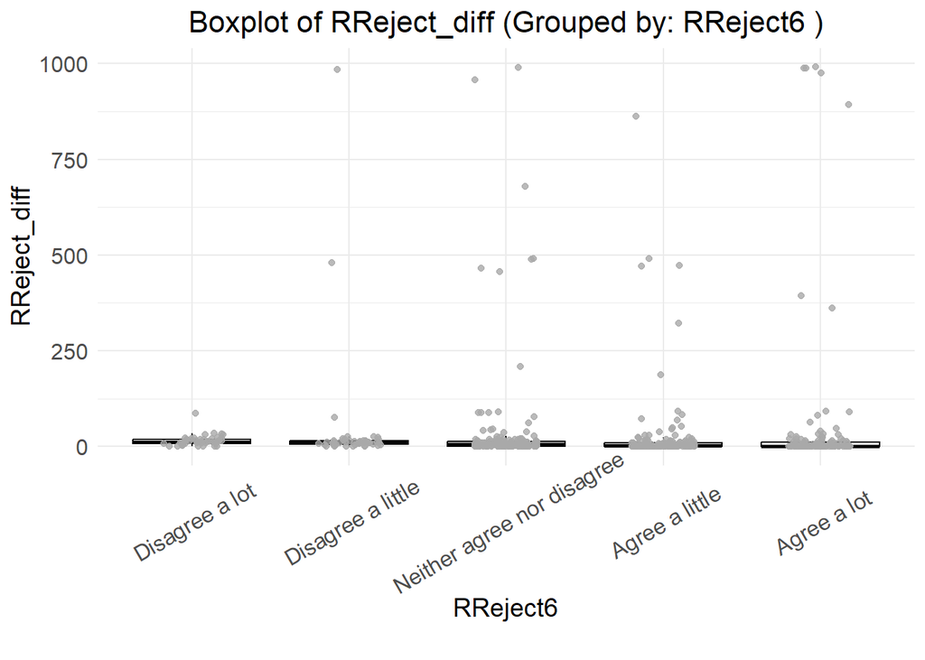

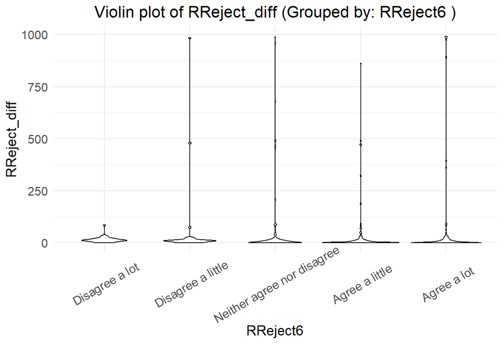

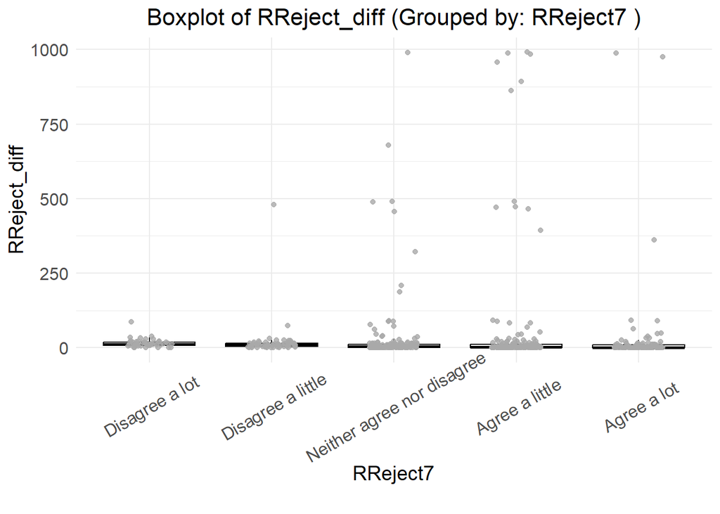

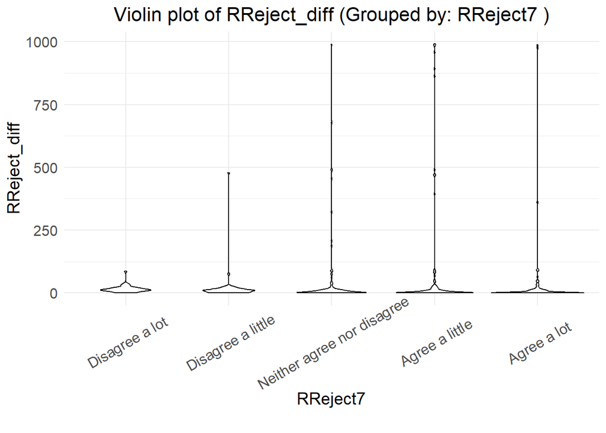

#### Difference filtered by less than 125

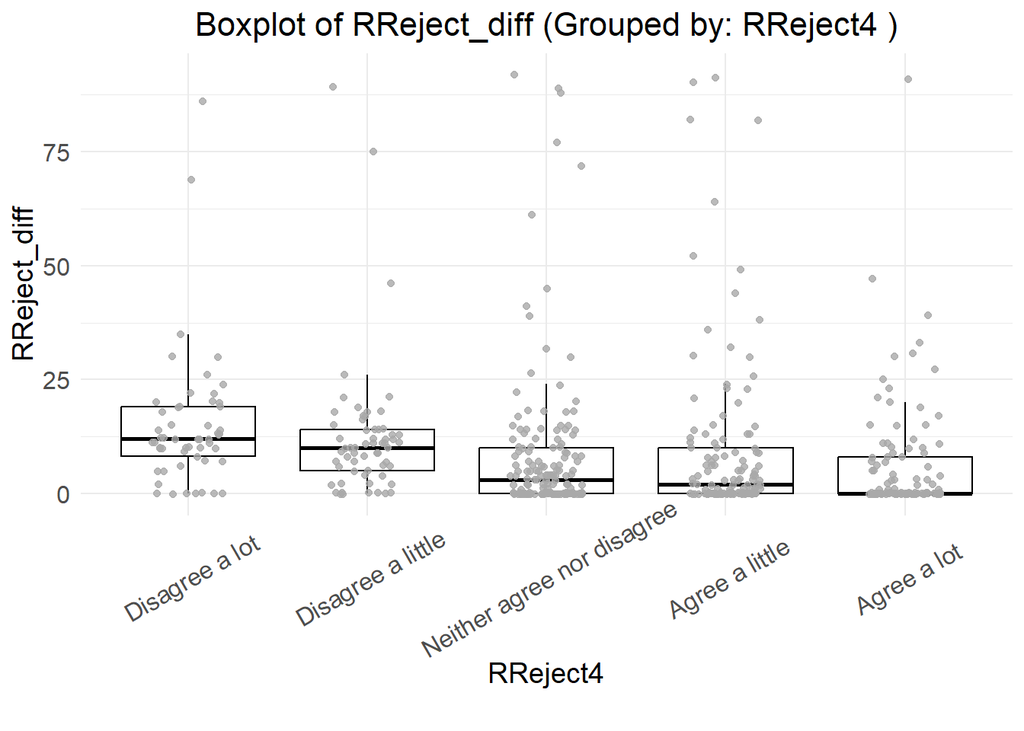

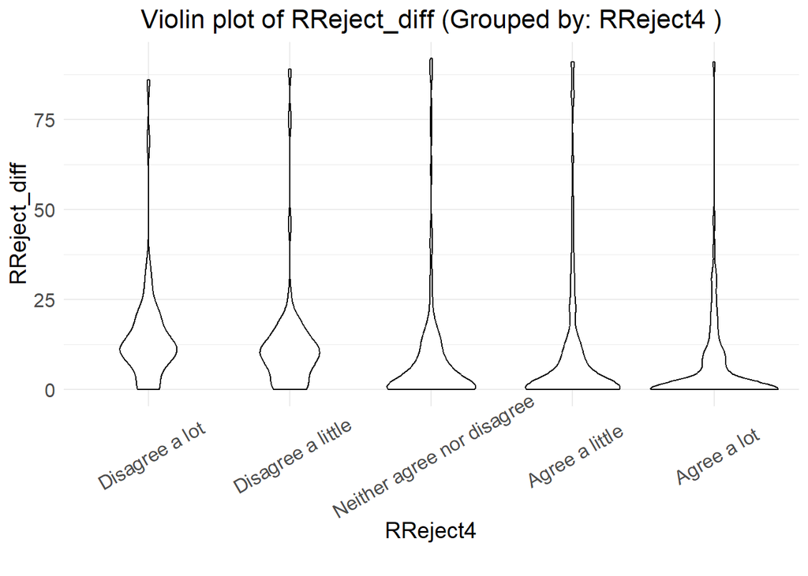

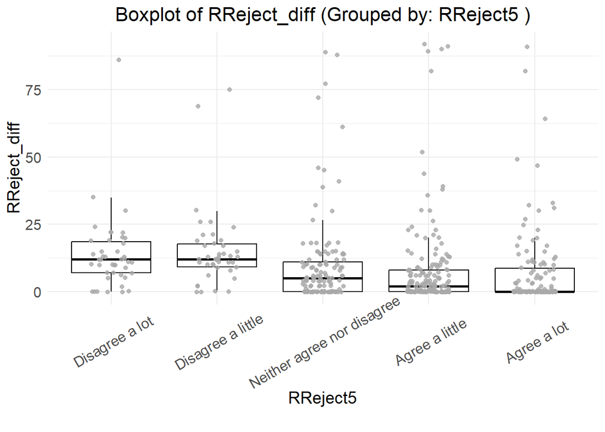

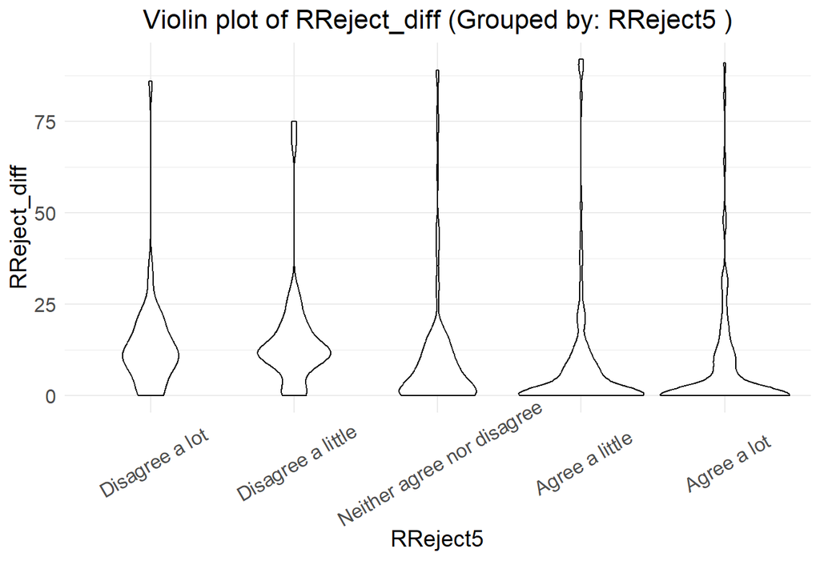

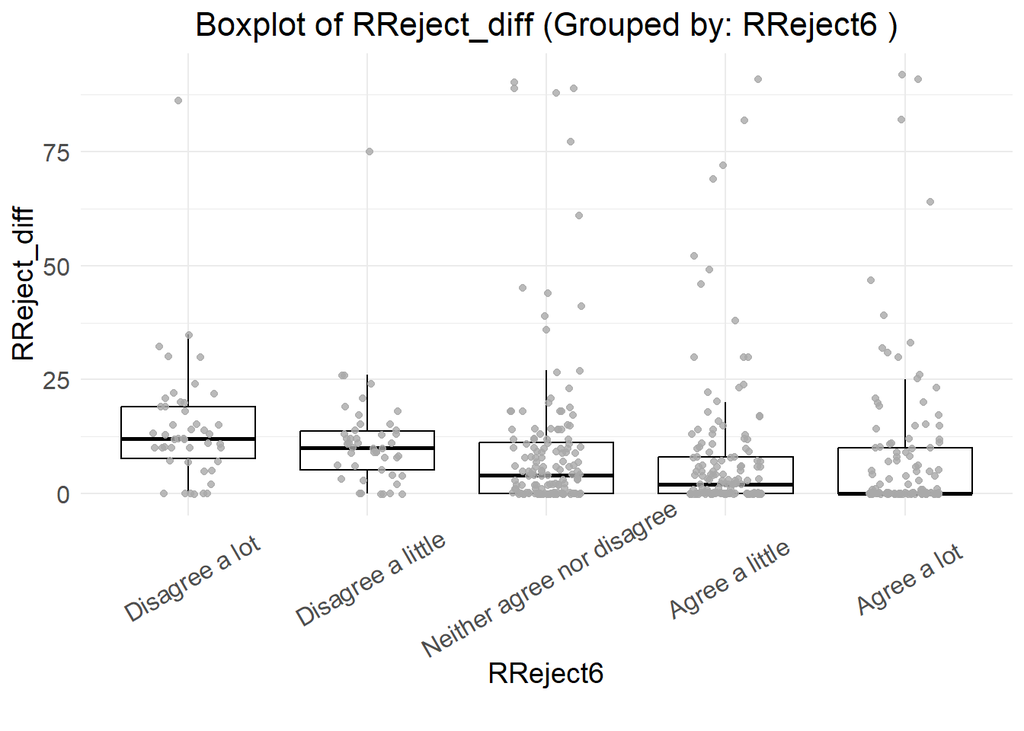

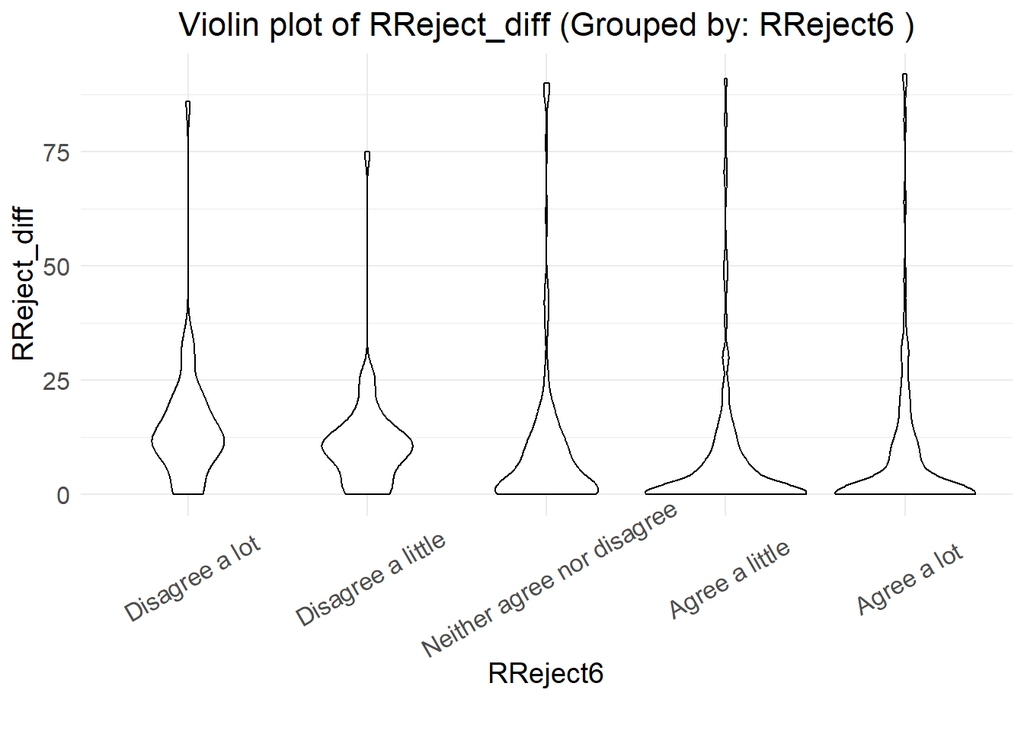

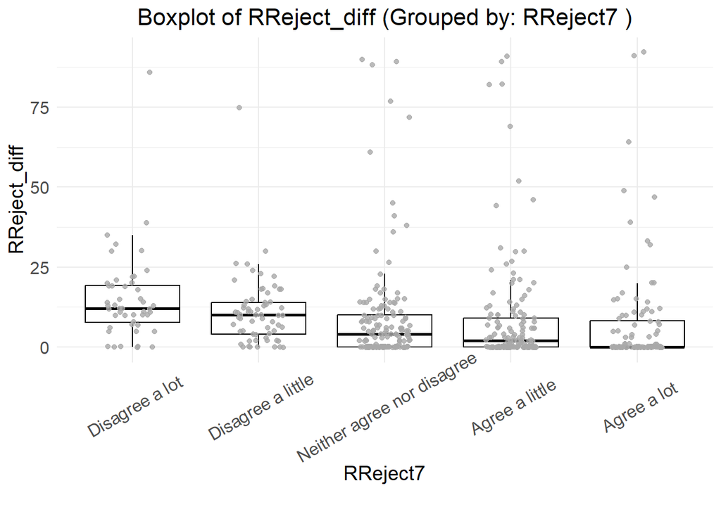

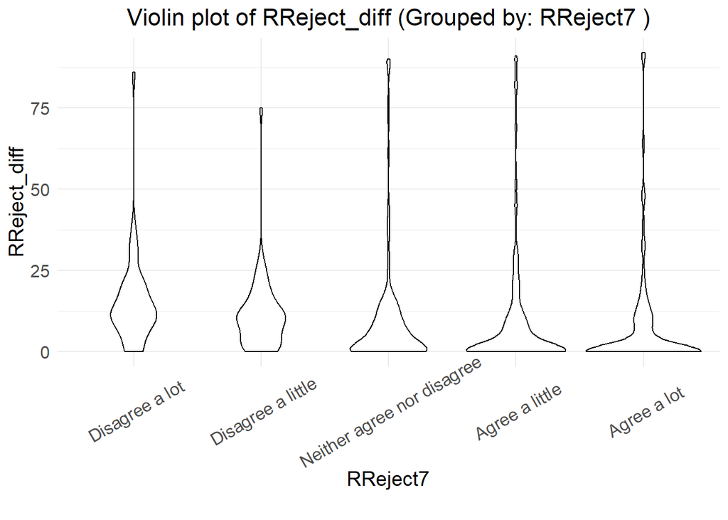

## Correlation Tests

**Summary**:  
In our case, there is **significant moderate negative correlation between RReject_mean and absolute values of RReject_diff** (RReject1 - abs_risk_rounded).

**Important:** Manually fix typos in RReject1.

- ResponseId abs_risk_rounded RReject1 RReject_diff RReject2
- R_1LUtAxnLeszwqkC 8 **0.008** -7.992 Using the percent above **(Change to 8)**
- R_28RFoTia7YU40yO 11 **0.011** -10.989 Same **(Change to 11)**
- R_3Mo4X2lgxig4ct9 16 **10000** 9984 Noa **(Change to 1000)**

### Cronbach’s Alpha Measurement for SubNum1 - SubNum3

Consistency of low numeracy:

- Q1: How good are you at working with fractions?
- Q2: How good are you at figuring out how much a shirt will cost if it is 25% off?
- Q3: How often do you find numerical information to be useful?

**Standardized Cronbach’s alpha for SubNum1 - SubNum3** is, 0.8142, a 95% Bootstrap CI based on 1000 samples is (0.7804, 0.8442).

There are 3 items, 527 sample units.

$\alpha \geq 0.9$: Excellent.

$0.9 \gt \alpha \geq 0.8$: Good.

$0.8 \gt \alpha \geq 0.7$: Acceptable.

### Correlation tests with all data points

**Problems:**  
- Outliers  
- Zero-inflated distribution or Zero-truncated distribution (RReject_diff)  
- Ordinal data, not continuous (RReject_mean, SubNum_mean)

**Preferred Method:** Spearman’s rank correlation coefficient.

The assumptions for Spearman’s Rho include:

- Continuous or ordinal
- Monotonicity

#### Descriptive Summary of RReject_mean

Descriptive Summary of RReject_mean

| mean | median | min | max | variance | sd | n_missing |
| --- | --- | --- | --- | --- | --- | --- |
| 3.444497 | 3.5 | 1 | 5 | 1.228496 | 1.108376 | 0 |

#### Descriptive Summary of SubNum_mean

Descriptive Summary of SubNum_mean

| mean | median | min | max | variance | sd | n_missing |
| --- | --- | --- | --- | --- | --- | --- |
| 3.923837 | 4 | 1 | 6 | 1.705618 | 1.305993 | 37 |

```
    Pearson's product-moment correlation

data:  df[["RReject_mean"]] and df[["SubNum_mean"]]
t = 1.5986, df = 488, p-value = 0.1106
alternative hypothesis: true correlation is not equal to 0
95 percent confidence interval:
 -0.01651165  0.15973597
sample estimates:
       cor
0.07217557
```

```
    Spearman's rank correlation rho

data:  df[["RReject_mean"]] and df[["SubNum_mean"]]
S = 18310949, p-value = 0.1437
alternative hypothesis: true rho is not equal to 0
sample estimates:
       rho
0.06615314
```

```
    Pearson's product-moment correlation

data:  df[["RReject_mean"]] and df[["RReject_diff"]]
t = 1.2161, df = 525, p-value = 0.2245
alternative hypothesis: true correlation is not equal to 0
95 percent confidence interval:
 -0.03256053  0.13778873
sample estimates:
       cor
0.05299967
```

```
    Pearson's product-moment correlation

data:  df[["SubNum_mean"]] and df[["RReject_diff"]]
t = 0.46282, df = 488, p-value = 0.6437
alternative hypothesis: true correlation is not equal to 0
95 percent confidence interval:
 -0.06776092  0.10932527
sample estimates:
       cor
0.02094647
```

```
    Spearman's rank correlation rho

data:  df[["RReject_mean"]] and df[["Abs_RReject_diff"]]
S = 31671529, p-value = 2.699e-12
alternative hypothesis: true rho is not equal to 0
sample estimates:
       rho
-0.2983447
```

```
    Spearman's rank correlation rho

data:  df[["SubNum_mean"]] and df[["Abs_RReject_diff"]]
S = 20116078, p-value = 0.5672
alternative hypothesis: true rho is not equal to 0
sample estimates:
        rho
-0.02590733
```

### Scatter plots with linear trend (all data points)

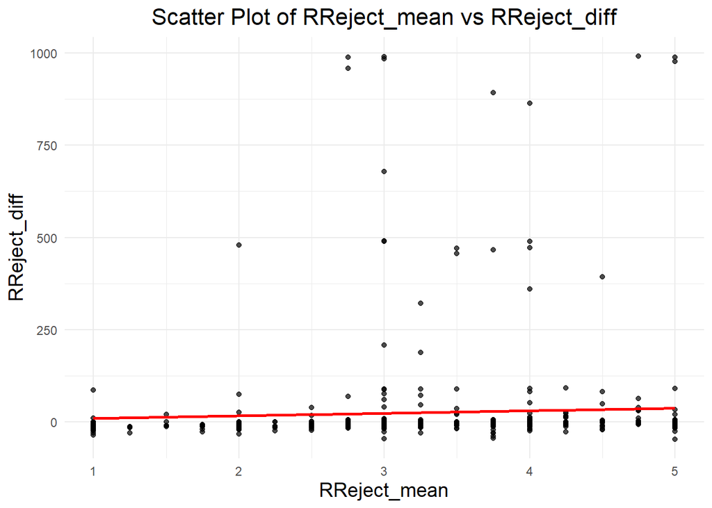

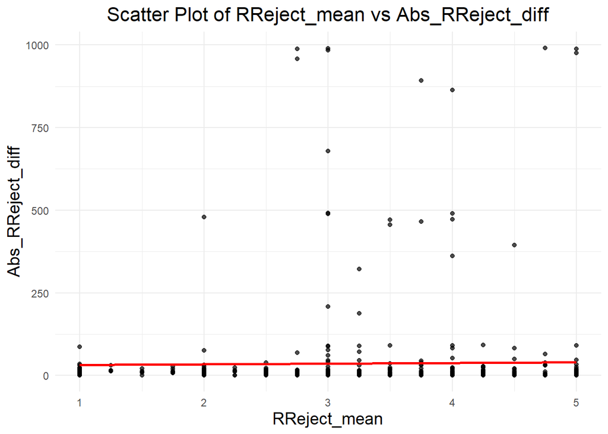

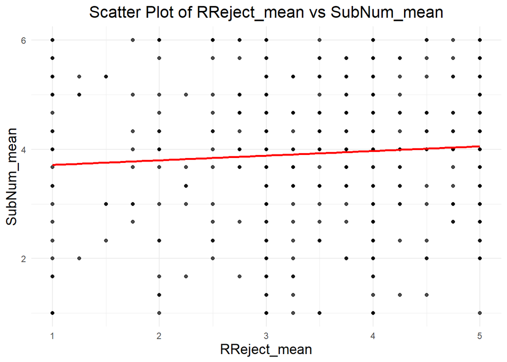

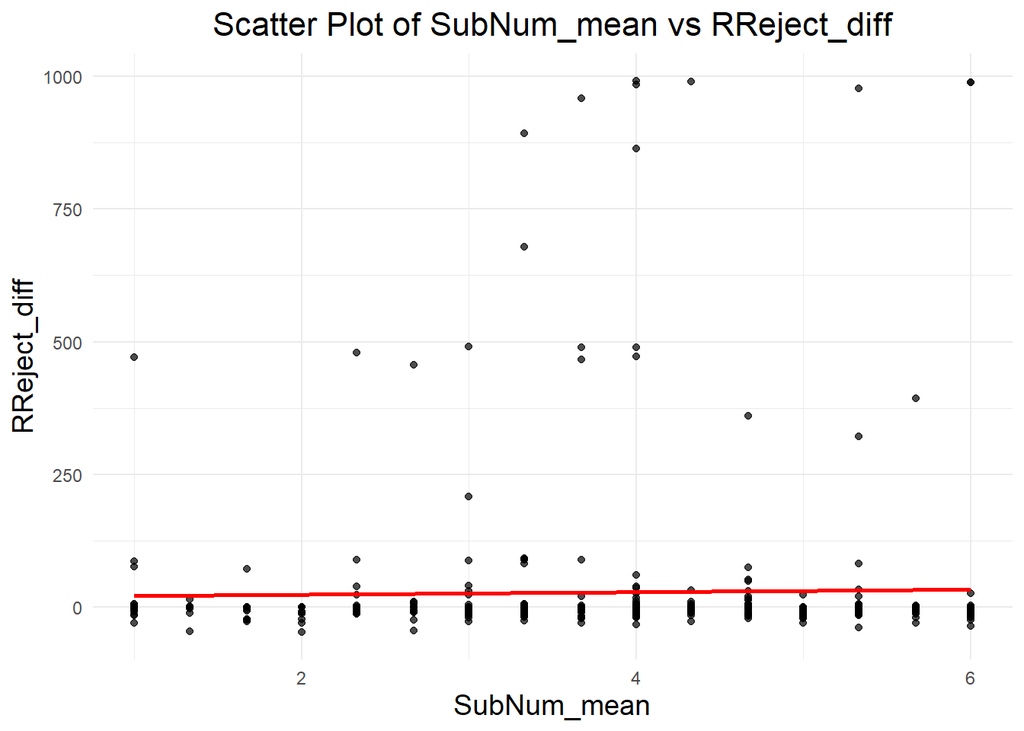

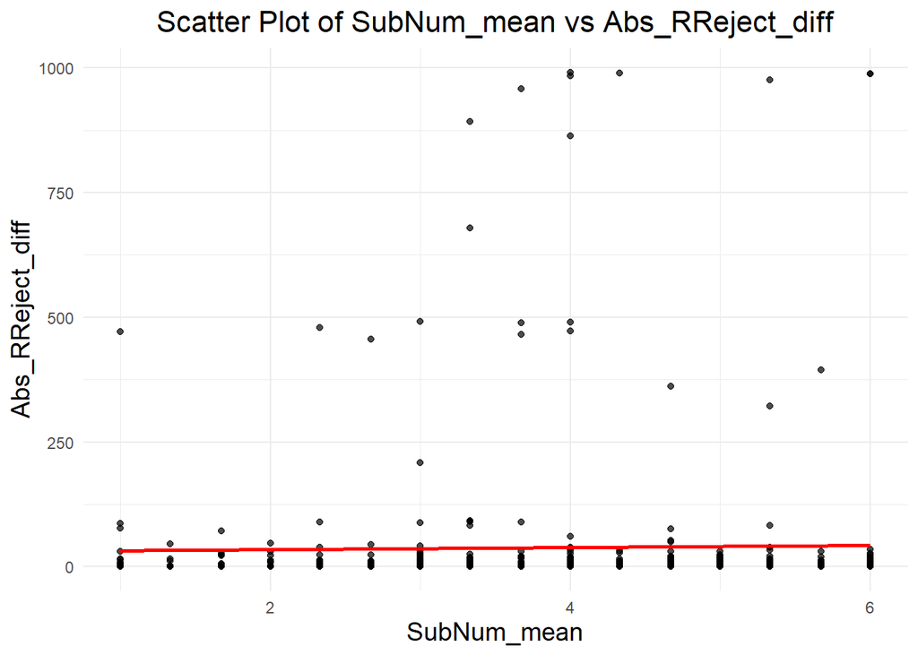

### Correlation tests without Outliers: filtering by Abs_RReject_diff < 125

```
    Pearson's product-moment correlation

data:  df[["RReject_mean"]] and df[["SubNum_mean"]]
t = 1.3211, df = 466, p-value = 0.1871
alternative hypothesis: true correlation is not equal to 0
95 percent confidence interval:
 -0.02972153  0.15089095
sample estimates:
       cor
0.06108472
```

```
    Spearman's rank correlation rho

data:  df[["RReject_mean"]] and df[["SubNum_mean"]]
S = 16180640, p-value = 0.2537
alternative hypothesis: true rho is not equal to 0
sample estimates:
      rho
0.0528661
```

```
    Pearson's product-moment correlation

data:  df[["RReject_mean"]] and df[["RReject_diff"]]
t = 3.9793, df = 502, p-value = 7.932e-05
alternative hypothesis: true correlation is not equal to 0
95 percent confidence interval:
 0.08888221 0.25826345
sample estimates:
      cor
0.1748663
```

```
    Pearson's product-moment correlation

data:  df[["SubNum_mean"]] and df[["RReject_diff"]]
t = -1.5545, df = 466, p-value = 0.1208
alternative hypothesis: true correlation is not equal to 0
95 percent confidence interval:
 -0.16141428  0.01894157
sample estimates:
        cor
-0.07182343
```

```
    Spearman's rank correlation rho

data:  df[["RReject_mean"]] and df[["Abs_RReject_diff"]]
S = 28298276, p-value = 5.808e-14
alternative hypothesis: true rho is not equal to 0
sample estimates:
       rho
-0.3262376
```

```
    Spearman's rank correlation rho

data:  df[["SubNum_mean"]] and df[["Abs_RReject_diff"]]
S = 17550636, p-value = 0.5554
alternative hypothesis: true rho is not equal to 0
sample estimates:
        rho
-0.02732663
```

#### Descriptive Summary of RReject_mean

Descriptive Summary of RReject_mean

| mean | median | min | max | variance | sd | n_missing |
| --- | --- | --- | --- | --- | --- | --- |
| 3.439484 | 3.5 | 1 | 5 | 1.25801 | 1.121611 | 0 |

#### Descriptive Summary of SubNum_mean

Descriptive Summary of SubNum_mean

| mean | median | min | max | variance | sd | n_missing |
| --- | --- | --- | --- | --- | --- | --- |
| 3.922393 | 4 | 1 | 6 | 1.718211 | 1.310805 | 36 |

### Scatter plots with linear trend (filtered data points)

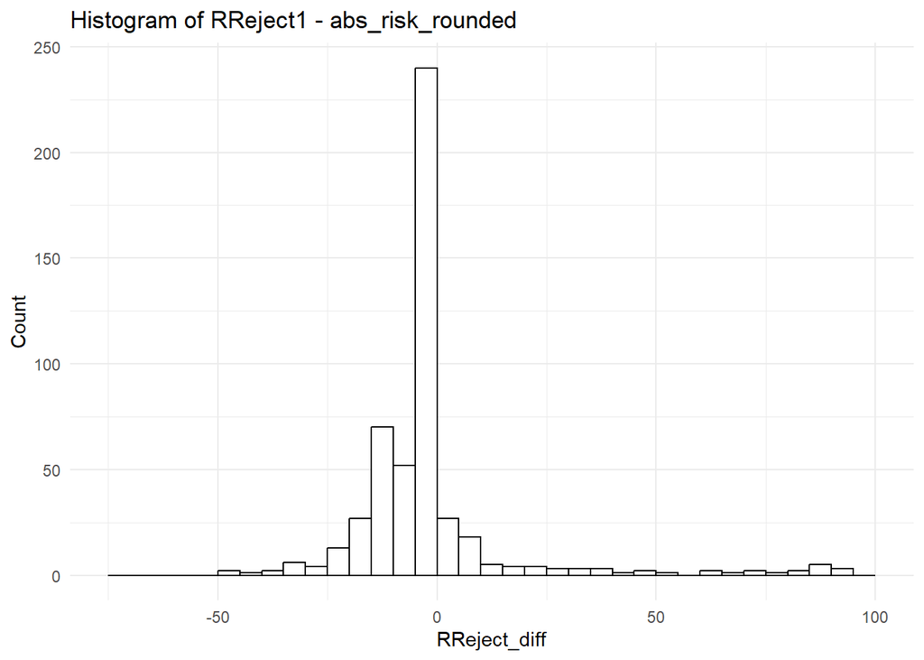

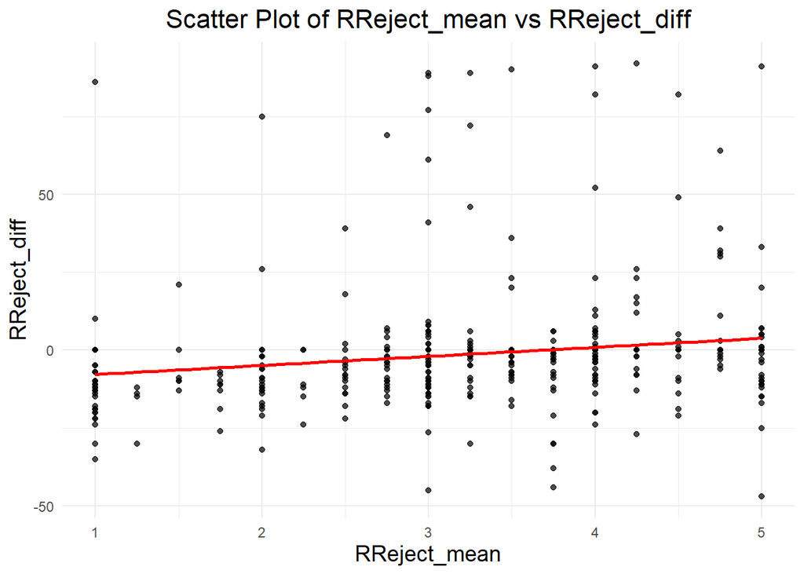

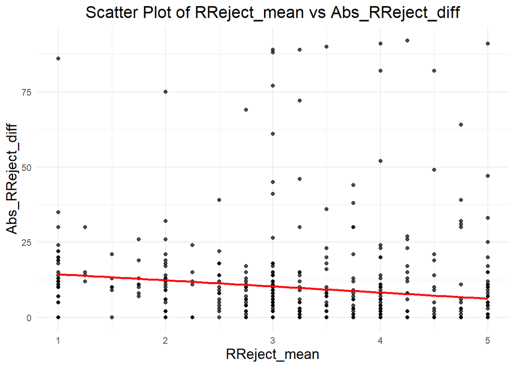

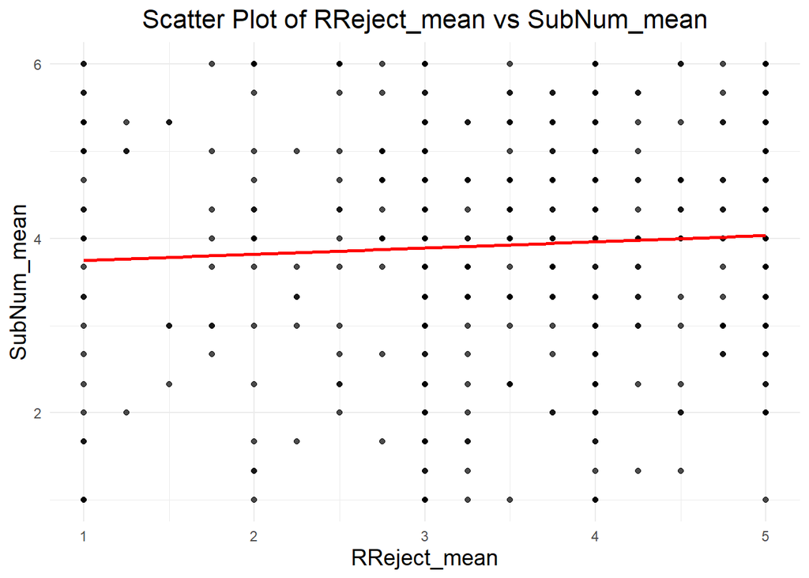

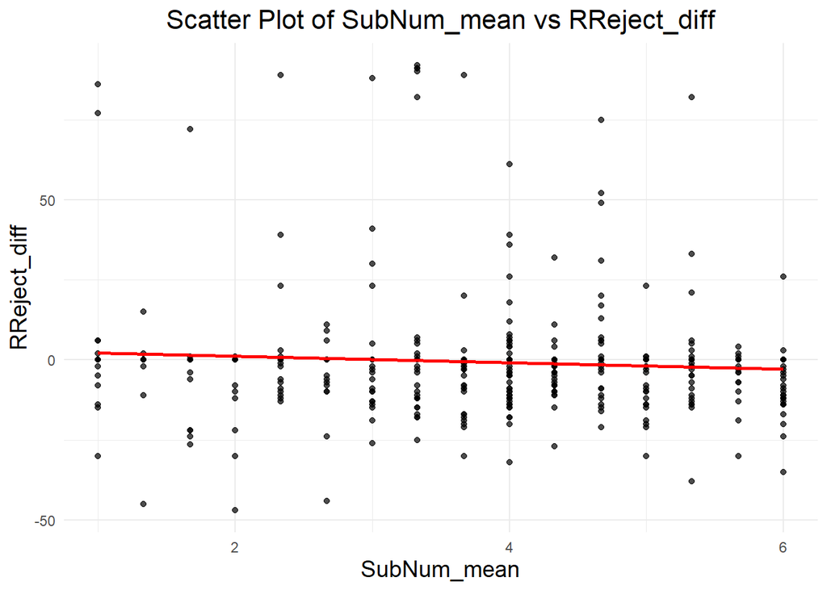

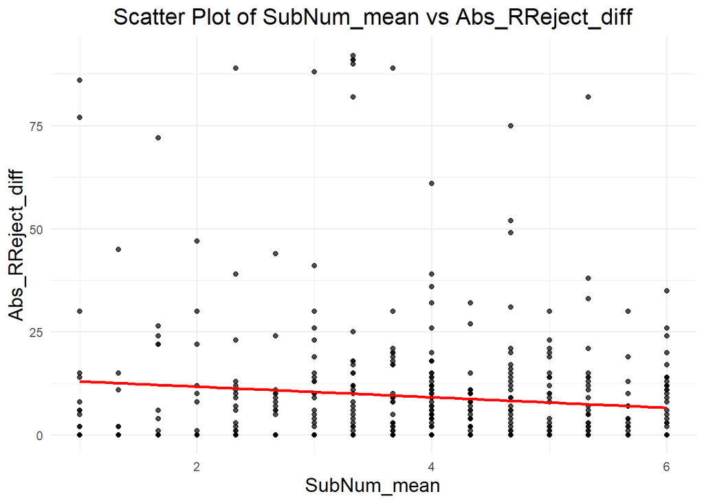